# Data Visualization Techniques - HW6 Report

Aleksandra Kulczycka

2022-12-28

# 1. Introduction

This report was created for a task in the course Data Visualization Techniques. We were tasked with describing one of the data visualization tools that wasn’t previously discussed, creating one visualization using this method, and presenting the source code. In carrying out this assignment, we worked in Rstudio. The report shows how we solved the task and the visualizations we created.

# 2. Tool Description

This report will describe the [Esquisse](https://cran.r-project.org/web/packages/esquisse/vignettes/get-started.html) addin and its application. The purpose of this add-in is to let you explore your data quickly to extract the information they hold. This addin allows you to interactively explore your data by visualizing it with the ggplot2 package. It allows you to draw bar plots, curves, scatter plots, histograms, boxplot and sf objects. You can quickly visualize your data accordingly to their type, export in various formats, and retrieve the code to reproduce the plot.

# 4. Making Visualizations using our tool

# 4.1. Installation

To install this R addin, run this command at your R prompt:

```r
 install.packages("esquisse")
 esquisse::esquisser()

 #you can also launch it with your data as below
 esquisse::esquisser(mtcars)
```

## 4.2. Import Data

If you didn’t load data when launching the addin, a window to import data will appear.

This feature comes from package {datamods}, you can find more documentation about it [here](https://dreamrs.github.io/datamods/articles/datamods.html).

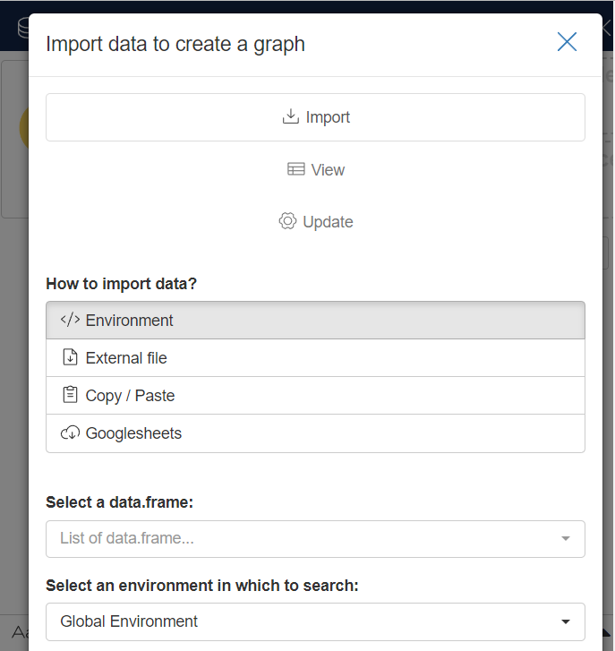

```r
#we launch the add-in and load the data
esquisse::esquisser()
```

But we are going to load the dataset “World” from R.

[figure not shown]

```r
#we launch the add-in and load the data
esquisse::esquisser(World)
```

## 4.3. Visualization Time

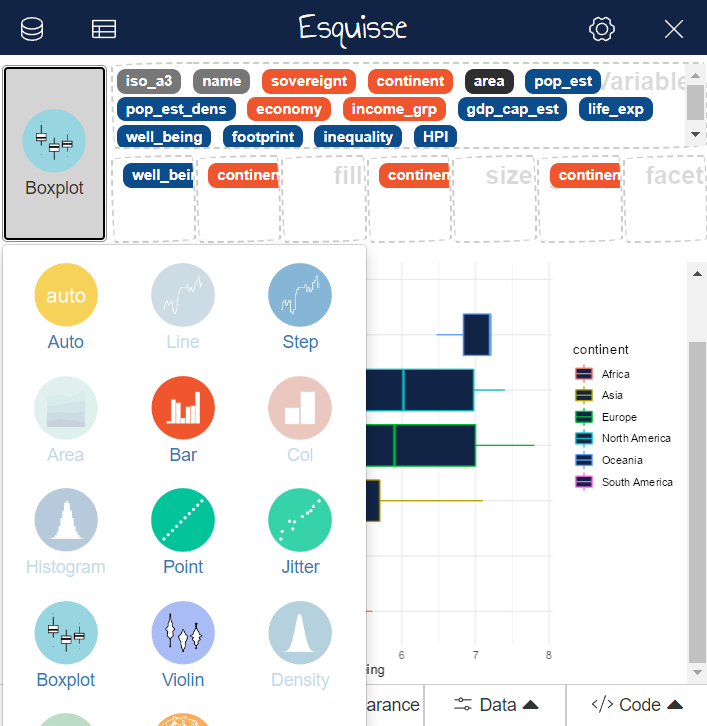

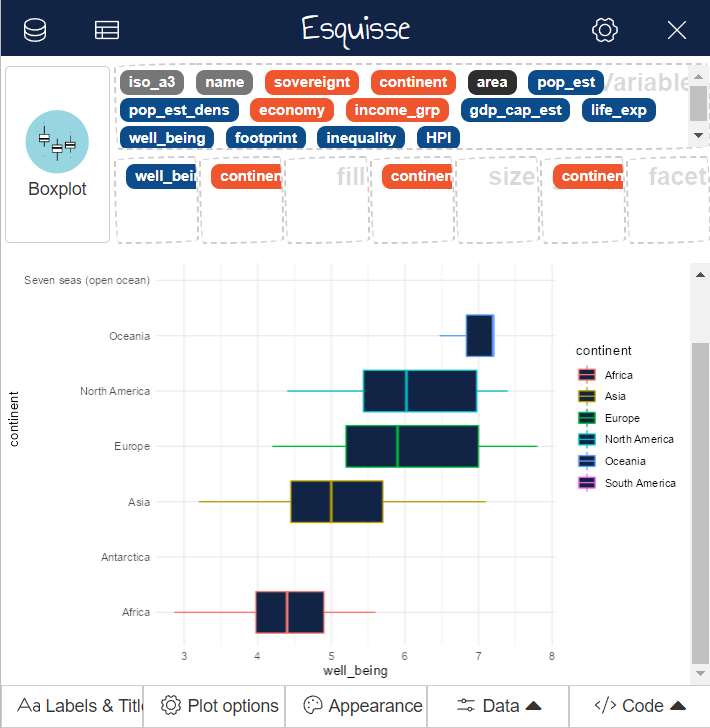

What’s interesting, the addin doesn’t allow us create some types of plots based on our dataset. For example in this case we can’t make Histogram or Line Plot.

What we can do, is easily set plot’s title, subtitle, caption and axis labels.

[figure not shown]

We are able to modify plot parameters as X-axis scale, and options available in the menu that mainly depend on the type of our plot:

[figure not shown]

It’s also very easy to modify colors and global theme, but what’s more interesting is the way Esquisse offers us the widgets to interactively filter data used in plot. We can change the range of data, remove any information that is not needed even if it’s based on the cells not used in the proccess of creation of the plot.

[figure not shown]

## 4.4. Export

We can save our beautiful plot in various formats by clicking the button in the top right corner:

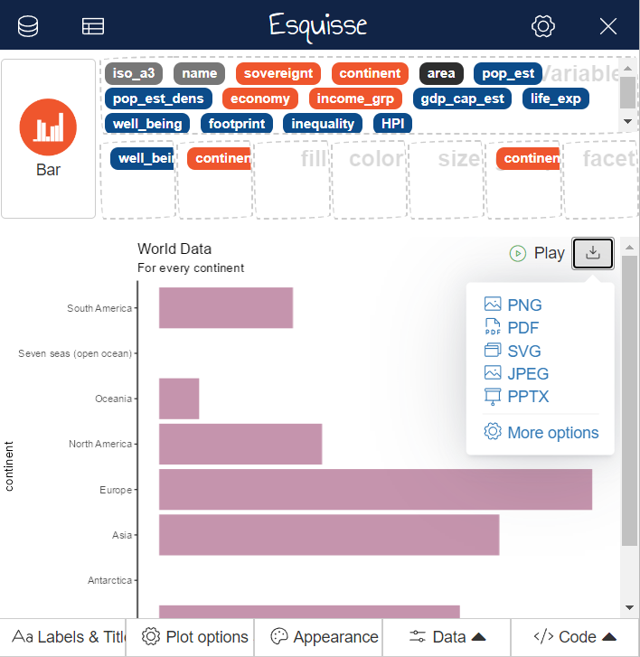

And what’s the best, here we can retrieve the code used to produce the plot, as well as the code used to filter the data.

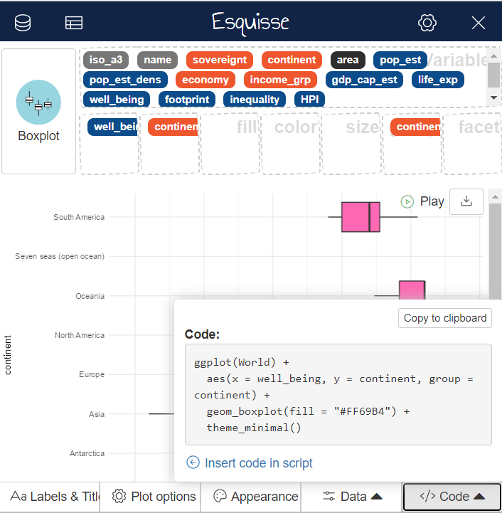

## 4.5 Tool’s different options

By default, Esquisse is launched into a dialog window,but we can also choose to use our browser if we want to.

```r
esquisse::esquisser(viewer = "browser")
```

# 5. Summary

Esquisse is really intuitive. It allows you to create numerous visualizations at once. It’s also interactive, making it very easy to use even for those who have nothing to do with data visualization.  
Of course, it probably has its drawbacks, like any other package. However I didn’t notice many of them in the process of creating these few charts. The only irritating one for me were the pop-up errors but it probably may be blocked.  
It has also many additional beneficial features that are not included in this report and I strongly recommend to read more about Esquisse [here](https://cran.r-project.org/web/packages/esquisse/vignettes/get-started.html)

### Bonus - little visualization in leaflet bc I thought it was not discussed in the course and it’s too brilliant to not be shown

Leaflet is one of the most popular open-source JavaScript libraries for interactive maps. It’s used by websites ranging from The New York Times and The Washington Post to GitHub and Flickr, as well as GIS specialists like OpenStreetMap, Mapbox, and CartoDB.

This R package makes it easy to integrate and control Leaflet maps in R.

```r
library(leaflet)
content <- paste(sep = "<br/>",
  "<b><a href='https://ww2.mini.pw.edu.pl/'>Glass Trap</a></b>",
  "Koszykowa 75",
  "Warsaw","Do not go there if you want to be mentally stable"
) # Create a vector containing a link and the content that you want to display
mini <- leaflet() %>%
  addTiles() %>%  # Add default OpenStreetMap map tiles
  addMarkers(lng=21.007004703008953, lat=52.2221473,popup=content, label = "Glass Trap. Click for more"
)

mini  # Print the map
```

[interactive chart not shown]